# Risk Factor Analysis

## Outcome Variable

**Outcome Variable:** whz

## Predictor Variables

**Intervention Variable:** exclfeed3

**Adjustment Set:**

- arm
- sex
- brthmon
- W_mage
- meducyrs
- feducyrs
- hhwealth_quart
- hfoodsec
- W_mhtcm
- W_mwtkg
- W_mbmi
- vagbrth
- W_gagebrth
- W_birthwt
- W_birthlen
- W_nrooms
- W_nchldlt5
- month
- W_parity
- impfloor
- impsan
- safeh20
- delta_W_mage
- delta_meducyrs
- delta_feducyrs
- delta_hhwealth_quart
- delta_hfoodsec
- delta_W_mhtcm
- delta_W_mwtkg
- delta_W_mbmi
- delta_vagbrth
- delta_W_gagebrth
- delta_W_birthwt
- delta_W_birthlen
- delta_W_nrooms
- delta_W_nchldlt5
- delta_month
- delta_W_parity
- delta_impfloor
- delta_impsan
- delta_safeh20

## Stratifying Variables

The analysis was stratified on these variable(s):

- agecat
- studyid
- country

## Data Summary

| agecat | studyid | country | exclfeed3 | n_cell | n |
| --- | --- | --- | --- | --- | --- |
| Birth | CMC-V-BCS-2002 | INDIA | 1 | 4 | 4 |
| Birth | CMC-V-BCS-2002 | INDIA | 0 | 0 | 4 |
| Birth | EE | PAKISTAN | 1 | 22 | 22 |
| Birth | EE | PAKISTAN | 0 | 0 | 22 |
| Birth | GMS-Nepal | NEPAL | 1 | 352 | 422 |
| Birth | GMS-Nepal | NEPAL | 0 | 70 | 422 |
| Birth | IRC | INDIA | 1 | 0 | 9 |
| Birth | IRC | INDIA | 0 | 9 | 9 |
| Birth | JiVitA-3 | BANGLADESH | 1 | 9636 | 10634 |
| Birth | JiVitA-3 | BANGLADESH | 0 | 998 | 10634 |
| Birth | JiVitA-4 | BANGLADESH | 1 | 89 | 97 |
| Birth | JiVitA-4 | BANGLADESH | 0 | 8 | 97 |
| Birth | Keneba | GAMBIA | 1 | 1133 | 1282 |
| Birth | Keneba | GAMBIA | 0 | 149 | 1282 |
| Birth | MAL-ED | BANGLADESH | 1 | 130 | 202 |
| Birth | MAL-ED | BANGLADESH | 0 | 72 | 202 |
| Birth | MAL-ED | BRAZIL | 1 | 11 | 55 |
| Birth | MAL-ED | BRAZIL | 0 | 44 | 55 |
| Birth | MAL-ED | INDIA | 1 | 22 | 39 |
| Birth | MAL-ED | INDIA | 0 | 17 | 39 |
| Birth | MAL-ED | NEPAL | 1 | 8 | 25 |
| Birth | MAL-ED | NEPAL | 0 | 17 | 25 |
| Birth | MAL-ED | PERU | 1 | 47 | 218 |
| Birth | MAL-ED | PERU | 0 | 171 | 218 |
| Birth | MAL-ED | SOUTH AFRICA | 1 | 12 | 99 |
| Birth | MAL-ED | SOUTH AFRICA | 0 | 87 | 99 |
| Birth | MAL-ED | TANZANIA, UNITED REPUBLIC OF | 1 | 15 | 95 |
| Birth | MAL-ED | TANZANIA, UNITED REPUBLIC OF | 0 | 80 | 95 |
| Birth | PROVIDE | BANGLADESH | 1 | 381 | 532 |
| Birth | PROVIDE | BANGLADESH | 0 | 151 | 532 |

[output cut: 64 more lines]

The following strata were considered:

- agecat: 24 months, studyid: CMC-V-BCS-2002, country: INDIA
- agecat: 24 months, studyid: EE, country: PAKISTAN
- agecat: 24 months, studyid: GMS-Nepal, country: NEPAL
- agecat: 24 months, studyid: IRC, country: INDIA
- agecat: 24 months, studyid: JiVitA-3, country: BANGLADESH
- agecat: 24 months, studyid: JiVitA-4, country: BANGLADESH
- agecat: 24 months, studyid: Keneba, country: GAMBIA
- agecat: 24 months, studyid: MAL-ED, country: BANGLADESH
- agecat: 24 months, studyid: MAL-ED, country: BRAZIL
- agecat: 24 months, studyid: MAL-ED, country: INDIA
- agecat: 24 months, studyid: MAL-ED, country: NEPAL
- agecat: 24 months, studyid: MAL-ED, country: PERU
- agecat: 24 months, studyid: MAL-ED, country: SOUTH AFRICA
- agecat: 24 months, studyid: MAL-ED, country: TANZANIA, UNITED REPUBLIC OF
- agecat: 24 months, studyid: PROVIDE, country: BANGLADESH
- agecat: 6 months, studyid: CMC-V-BCS-2002, country: INDIA
- agecat: 6 months, studyid: EE, country: PAKISTAN
- agecat: 6 months, studyid: GMS-Nepal, country: NEPAL
- agecat: 6 months, studyid: IRC, country: INDIA
- agecat: 6 months, studyid: JiVitA-3, country: BANGLADESH
- agecat: 6 months, studyid: JiVitA-4, country: BANGLADESH
- agecat: 6 months, studyid: Keneba, country: GAMBIA
- agecat: 6 months, studyid: MAL-ED, country: BANGLADESH
- agecat: 6 months, studyid: MAL-ED, country: BRAZIL
- agecat: 6 months, studyid: MAL-ED, country: INDIA
- agecat: 6 months, studyid: MAL-ED, country: NEPAL
- agecat: 6 months, studyid: MAL-ED, country: PERU
- agecat: 6 months, studyid: MAL-ED, country: SOUTH AFRICA
- agecat: 6 months, studyid: MAL-ED, country: TANZANIA, UNITED REPUBLIC OF
- agecat: 6 months, studyid: PROVIDE, country: BANGLADESH
- agecat: 6 months, studyid: SAS-CompFeed, country: INDIA
- agecat: Birth, studyid: CMC-V-BCS-2002, country: INDIA
- agecat: Birth, studyid: EE, country: PAKISTAN
- agecat: Birth, studyid: GMS-Nepal, country: NEPAL
- agecat: Birth, studyid: IRC, country: INDIA
- agecat: Birth, studyid: JiVitA-3, country: BANGLADESH
- agecat: Birth, studyid: JiVitA-4, country: BANGLADESH
- agecat: Birth, studyid: Keneba, country: GAMBIA
- agecat: Birth, studyid: MAL-ED, country: BANGLADESH
- agecat: Birth, studyid: MAL-ED, country: BRAZIL
- agecat: Birth, studyid: MAL-ED, country: INDIA
- agecat: Birth, studyid: MAL-ED, country: NEPAL
- agecat: Birth, studyid: MAL-ED, country: PERU
- agecat: Birth, studyid: MAL-ED, country: SOUTH AFRICA
- agecat: Birth, studyid: MAL-ED, country: TANZANIA, UNITED REPUBLIC OF
- agecat: Birth, studyid: PROVIDE, country: BANGLADESH
- agecat: Birth, studyid: SAS-CompFeed, country: INDIA

### Dropped Strata

Some strata were dropped due to rare outcomes:

- agecat: Birth, studyid: CMC-V-BCS-2002, country: INDIA
- agecat: Birth, studyid: EE, country: PAKISTAN
- agecat: Birth, studyid: IRC, country: INDIA
- agecat: 6 months, studyid: CMC-V-BCS-2002, country: INDIA
- agecat: 6 months, studyid: EE, country: PAKISTAN
- agecat: 6 months, studyid: IRC, country: INDIA
- agecat: 24 months, studyid: CMC-V-BCS-2002, country: INDIA
- agecat: 24 months, studyid: EE, country: PAKISTAN
- agecat: 24 months, studyid: IRC, country: INDIA

## Methods Detail

We’re interested in the causal parameters $E[Y_a]$ for all values of $a \in \mathcal{A}$. These parameters represent the mean outcome if, possibly contrary to fact, we intervened to set all units to have $A=a$. Under the randomization and positivity assumptions, these are identified by the statistical parameters $\psi_a=E_W[E_{Y|A,W}(Y|A=a,W)]$. In addition, we’re interested in the mean of $Y$, $E[Y]$ under no intervention (the observed mean). We will estimate these parameters by using SuperLearner to fit the relevant likelihood factors – $E_{Y|A,W}(Y|A=a,W)$ and $p(A=a|W)$, and then updating our likelihood fit using a joint TMLE.

For unadjusted analyses ($W=\{\}$), initial likelihoods were estimated using Lrnr_glm to estimate the simple $E(Y|A)$ and Lrnr_mean to estimate $p(A)$. For adjusted analyses, a small library containing Lrnr_glmnet, Lrnr_xgboost, and Lrnr_mean was used.

Having estimated these parameters, we will then use the delta method to estimate relative risks and attributable risks relative to a prespecified baseline level of $A$.

# Results Detail

## Results Plots

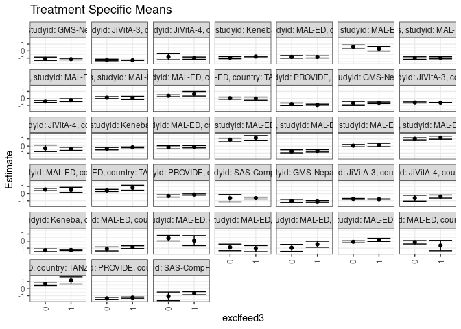

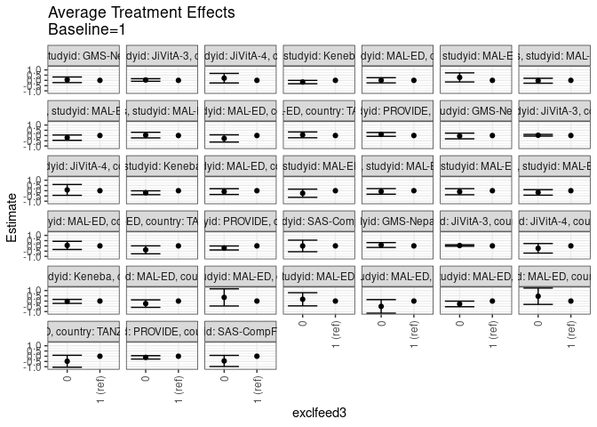

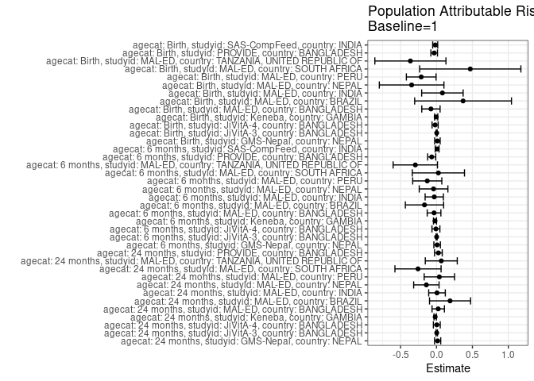

## Results Table

### Parameter: TSM

| agecat | studyid | country | intervention_level | baseline_level | estimate | ci_lower | ci_upper |
| --- | --- | --- | --- | --- | --- | --- | --- |
| Birth | GMS-Nepal | NEPAL | 1 | NA | -1.1120763 | -1.2308966 | -0.9932560 |
| Birth | GMS-Nepal | NEPAL | 0 | NA | -1.0293886 | -1.2408308 | -0.8179464 |
| Birth | JiVitA-3 | BANGLADESH | 1 | NA | -0.7830241 | -0.8062645 | -0.7597836 |
| Birth | JiVitA-3 | BANGLADESH | 0 | NA | -0.7499306 | -0.8163783 | -0.6834828 |
| Birth | JiVitA-4 | BANGLADESH | 1 | NA | -0.4156180 | -0.6383645 | -0.1928714 |
| Birth | JiVitA-4 | BANGLADESH | 0 | NA | -0.6475000 | -1.0569566 | -0.2380434 |
| Birth | Keneba | GAMBIA | 1 | NA | -1.2586423 | -1.3266868 | -1.1905978 |
| Birth | Keneba | GAMBIA | 0 | NA | -1.2906561 | -1.4740124 | -1.1072999 |
| Birth | MAL-ED | BANGLADESH | 1 | NA | -0.8639625 | -1.0613697 | -0.6665552 |
| Birth | MAL-ED | BANGLADESH | 0 | NA | -1.1059116 | -1.3789865 | -0.8328367 |
| Birth | MAL-ED | BRAZIL | 1 | NA | 0.0616449 | -0.6470906 | 0.7703804 |
| Birth | MAL-ED | BRAZIL | 0 | NA | 0.4107420 | 0.0256865 | 0.7957974 |
| Birth | MAL-ED | INDIA | 1 | NA | -1.0603923 | -1.4761813 | -0.6446032 |
| Birth | MAL-ED | INDIA | 0 | NA | -0.8907536 | -1.3524780 | -0.4290292 |
| Birth | MAL-ED | NEPAL | 1 | NA | -0.4487500 | -0.8783289 | -0.0191711 |
| Birth | MAL-ED | NEPAL | 0 | NA | -0.9570588 | -1.4394884 | -0.4746293 |
| Birth | MAL-ED | PERU | 1 | NA | 0.1788673 | -0.0449332 | 0.4026678 |
| Birth | MAL-ED | PERU | 0 | NA | -0.0965866 | -0.2384133 | 0.0452402 |
| Birth | MAL-ED | SOUTH AFRICA | 1 | NA | -0.6291708 | -1.3595136 | 0.1011719 |
| Birth | MAL-ED | SOUTH AFRICA | 0 | NA | -0.1692285 | -0.4114046 | 0.0729477 |
| Birth | MAL-ED | TANZANIA, UNITED REPUBLIC OF | 1 | NA | 1.1624240 | 0.6465444 | 1.6783035 |
| Birth | MAL-ED | TANZANIA, UNITED REPUBLIC OF | 0 | NA | 0.6845618 | 0.4530332 | 0.9160904 |
| Birth | PROVIDE | BANGLADESH | 1 | NA | -1.2667741 | -1.3553267 | -1.1782214 |
| Birth | PROVIDE | BANGLADESH | 0 | NA | -1.3746977 | -1.5166025 | -1.2327929 |
| Birth | SAS-CompFeed | INDIA | 1 | NA | -0.6419787 | -0.8661092 | -0.4178481 |
| Birth | SAS-CompFeed | INDIA | 0 | NA | -1.0901281 | -1.7027393 | -0.4775170 |
| 6 months | GMS-Nepal | NEPAL | 1 | NA | -0.6289951 | -0.7390389 | -0.5189513 |
| 6 months | GMS-Nepal | NEPAL | 0 | NA | -0.6734089 | -0.9209063 | -0.4259115 |
| 6 months | JiVitA-3 | BANGLADESH | 1 | NA | -0.6061867 | -0.6317355 | -0.5806378 |
| 6 months | JiVitA-3 | BANGLADESH | 0 | NA | -0.5813002 | -0.6588647 | -0.5037357 |
| 6 months | JiVitA-4 | BANGLADESH | 1 | NA | -0.4033665 | -0.6309351 | -0.1757980 |
| 6 months | JiVitA-4 | BANGLADESH | 0 | NA | -0.3265596 | -0.7924123 | 0.1392930 |
| 6 months | Keneba | GAMBIA | 1 | NA | -0.1851632 | -0.2435155 | -0.1268109 |
| 6 months | Keneba | GAMBIA | 0 | NA | -0.3784326 | -0.5534938 | -0.2033715 |
| 6 months | MAL-ED | BANGLADESH | 1 | NA | -0.0967151 | -0.2625786 | 0.0691484 |
| 6 months | MAL-ED | BANGLADESH | 0 | NA | -0.1832358 | -0.4036478 | 0.0371761 |
| 6 months | MAL-ED | BRAZIL | 1 | NA | 1.1421364 | 0.8138535 | 1.4704193 |
| 6 months | MAL-ED | BRAZIL | 0 | NA | 0.8991942 | 0.6900910 | 1.1082975 |
| 6 months | MAL-ED | INDIA | 1 | NA | -0.6875334 | -0.8513298 | -0.5237369 |
| 6 months | MAL-ED | INDIA | 0 | NA | -0.7568846 | -0.9673678 | -0.5464014 |
| 6 months | MAL-ED | NEPAL | 1 | NA | 0.1445798 | -0.0954902 | 0.3846498 |
| 6 months | MAL-ED | NEPAL | 0 | NA | 0.0493907 | -0.1116643 | 0.2104456 |
| 6 months | MAL-ED | PERU | 1 | NA | 1.1795403 | 0.9632025 | 1.3958781 |
| 6 months | MAL-ED | PERU | 0 | NA | 1.0179065 | 0.8725963 | 1.1632167 |
| 6 months | MAL-ED | SOUTH AFRICA | 1 | NA | 0.5299467 | 0.1770231 | 0.8828704 |
| 6 months | MAL-ED | SOUTH AFRICA | 0 | NA | 0.5749243 | 0.4117206 | 0.7381281 |
| 6 months | MAL-ED | TANZANIA, UNITED REPUBLIC OF | 1 | NA | 0.8204636 | 0.4716901 | 1.1692371 |
| 6 months | MAL-ED | TANZANIA, UNITED REPUBLIC OF | 0 | NA | 0.4445164 | 0.2925998 | 0.5964330 |
| 6 months | PROVIDE | BANGLADESH | 1 | NA | -0.1322812 | -0.2266797 | -0.0378827 |
| 6 months | PROVIDE | BANGLADESH | 0 | NA | -0.3322199 | -0.4979375 | -0.1665023 |
| 6 months | SAS-CompFeed | INDIA | 1 | NA | -0.6438016 | -0.7819173 | -0.5056859 |
| 6 months | SAS-CompFeed | INDIA | 0 | NA | -0.6500492 | -1.1672739 | -0.1328245 |
| 24 months | GMS-Nepal | NEPAL | 1 | NA | -1.1558253 | -1.2683465 | -1.0433041 |
| 24 months | GMS-Nepal | NEPAL | 0 | NA | -1.1006581 | -1.3424848 | -0.8588314 |
| 24 months | JiVitA-3 | BANGLADESH | 1 | NA | -1.3143348 | -1.3461492 | -1.2825205 |
| 24 months | JiVitA-3 | BANGLADESH | 0 | NA | -1.2802384 | -1.4009734 | -1.1595034 |
| 24 months | JiVitA-4 | BANGLADESH | 1 | NA | -1.0142043 | -1.1771931 | -0.8512156 |
| 24 months | JiVitA-4 | BANGLADESH | 0 | NA | -0.8064235 | -1.2332731 | -0.3795739 |
| 24 months | Keneba | GAMBIA | 1 | NA | -0.7750079 | -0.8292000 | -0.7208158 |
| 24 months | Keneba | GAMBIA | 0 | NA | -0.9387723 | -1.0889487 | -0.7885958 |
| 24 months | MAL-ED | BANGLADESH | 1 | NA | -0.8318500 | -0.9886444 | -0.6750556 |
| 24 months | MAL-ED | BANGLADESH | 0 | NA | -0.8249423 | -1.0138008 | -0.6360837 |
| 24 months | MAL-ED | BRAZIL | 1 | NA | 0.3090799 | -0.0230680 | 0.6412277 |
| 24 months | MAL-ED | BRAZIL | 0 | NA | 0.5920933 | 0.3098674 | 0.8743192 |
| 24 months | MAL-ED | INDIA | 1 | NA | -0.9591127 | -1.1073146 | -0.8109107 |
| 24 months | MAL-ED | INDIA | 0 | NA | -0.9973673 | -1.1808668 | -0.8138677 |
| 24 months | MAL-ED | NEPAL | 1 | NA | -0.2383317 | -0.4480878 | -0.0285756 |
| 24 months | MAL-ED | NEPAL | 0 | NA | -0.4422899 | -0.5842041 | -0.3003758 |
| 24 months | MAL-ED | PERU | 1 | NA | 0.0776589 | -0.1535401 | 0.3088580 |
| 24 months | MAL-ED | PERU | 0 | NA | 0.1195566 | -0.0185562 | 0.2576694 |
| 24 months | MAL-ED | SOUTH AFRICA | 1 | NA | 0.6688604 | 0.3498710 | 0.9878498 |
| 24 months | MAL-ED | SOUTH AFRICA | 0 | NA | 0.3914911 | 0.2611754 | 0.5218068 |
| 24 months | MAL-ED | TANZANIA, UNITED REPUBLIC OF | 1 | NA | -0.0171003 | -0.2447297 | 0.2105291 |
| 24 months | MAL-ED | TANZANIA, UNITED REPUBLIC OF | 0 | NA | 0.0497839 | -0.1103424 | 0.2099102 |
| 24 months | PROVIDE | BANGLADESH | 1 | NA | -0.9193728 | -1.0157649 | -0.8229807 |
| 24 months | PROVIDE | BANGLADESH | 0 | NA | -0.8120411 | -0.9689062 | -0.6551761 |

### Parameter: E(Y)

| agecat | studyid | country | intervention_level | baseline_level | estimate | ci_lower | ci_upper |
| --- | --- | --- | --- | --- | --- | --- | --- |
| Birth | GMS-Nepal | NEPAL | NA | NA | -1.0991706 | -1.2073693 | -0.9909719 |
| Birth | JiVitA-3 | BANGLADESH | NA | NA | -0.7798636 | -0.8022140 | -0.7575133 |
| Birth | JiVitA-4 | BANGLADESH | NA | NA | -0.4347423 | -0.6441144 | -0.2253701 |
| Birth | Keneba | GAMBIA | NA | NA | -1.2629563 | -1.3291505 | -1.1967622 |
| Birth | MAL-ED | BANGLADESH | NA | NA | -0.9411386 | -1.0895370 | -0.7927402 |
| Birth | MAL-ED | BRAZIL | NA | NA | 0.4316364 | 0.0969688 | 0.7663039 |
| Birth | MAL-ED | INDIA | NA | NA | -0.9779487 | -1.2664810 | -0.6894164 |
| Birth | MAL-ED | NEPAL | NA | NA | -0.7944000 | -1.1625222 | -0.4262778 |
| Birth | MAL-ED | PERU | NA | NA | -0.0335321 | -0.1564905 | 0.0894263 |
| Birth | MAL-ED | SOUTH AFRICA | NA | NA | -0.1588889 | -0.3845288 | 0.0667510 |
| Birth | MAL-ED | TANZANIA, UNITED REPUBLIC OF | NA | NA | 0.7996842 | 0.5874808 | 1.0118876 |
| Birth | PROVIDE | BANGLADESH | NA | NA | -1.2984586 | -1.3752758 | -1.2216415 |
| Birth | SAS-CompFeed | INDIA | NA | NA | -0.6596308 | -0.9005716 | -0.4186900 |
| 6 months | GMS-Nepal | NEPAL | NA | NA | -0.6198791 | -0.7206518 | -0.5191063 |
| 6 months | JiVitA-3 | BANGLADESH | NA | NA | -0.6040977 | -0.6286619 | -0.5795335 |
| 6 months | JiVitA-4 | BANGLADESH | NA | NA | -0.4110227 | -0.6122701 | -0.2097753 |
| 6 months | Keneba | GAMBIA | NA | NA | -0.2057183 | -0.2614359 | -0.1500006 |
| 6 months | MAL-ED | BANGLADESH | NA | NA | -0.1304936 | -0.2625419 | 0.0015547 |
| 6 months | MAL-ED | BRAZIL | NA | NA | 0.9754144 | 0.7990651 | 1.1517638 |
| 6 months | MAL-ED | INDIA | NA | NA | -0.7185992 | -0.8491469 | -0.5880515 |
| 6 months | MAL-ED | NEPAL | NA | NA | 0.1041483 | -0.0311352 | 0.2394318 |
| 6 months | MAL-ED | PERU | NA | NA | 1.0514136 | 0.9289176 | 1.1739096 |
| 6 months | MAL-ED | SOUTH AFRICA | NA | NA | 0.5564071 | 0.4055220 | 0.7072922 |
| 6 months | MAL-ED | TANZANIA, UNITED REPUBLIC OF | NA | NA | 0.5257626 | 0.3871543 | 0.6643709 |
| 6 months | PROVIDE | BANGLADESH | NA | NA | -0.1990907 | -0.2817968 | -0.1163845 |
| 6 months | SAS-CompFeed | INDIA | NA | NA | -0.6348861 | -0.7630511 | -0.5067211 |
| 24 months | GMS-Nepal | NEPAL | NA | NA | -1.1396441 | -1.2416403 | -1.0376479 |
| 24 months | JiVitA-3 | BANGLADESH | NA | NA | -1.3109518 | -1.3423299 | -1.2795737 |
| 24 months | JiVitA-4 | BANGLADESH | NA | NA | -1.0096000 | -1.1619164 | -0.8572836 |
| 24 months | Keneba | GAMBIA | NA | NA | -0.7930925 | -0.8442611 | -0.7419240 |
| 24 months | MAL-ED | BANGLADESH | NA | NA | -0.8076829 | -0.9296166 | -0.6857493 |
| 24 months | MAL-ED | BRAZIL | NA | NA | 0.4981140 | 0.2760418 | 0.7201863 |
| 24 months | MAL-ED | INDIA | NA | NA | -0.9516832 | -1.0703961 | -0.8329703 |
| 24 months | MAL-ED | NEPAL | NA | NA | -0.3790455 | -0.4958857 | -0.2622052 |
| 24 months | MAL-ED | PERU | NA | NA | 0.1176052 | -0.0015211 | 0.2367315 |
| 24 months | MAL-ED | SOUTH AFRICA | NA | NA | 0.4120797 | 0.2900939 | 0.5340654 |
| 24 months | MAL-ED | TANZANIA, UNITED REPUBLIC OF | NA | NA | 0.0495743 | -0.0857535 | 0.1849021 |
| 24 months | PROVIDE | BANGLADESH | NA | NA | -0.8928670 | -0.9755153 | -0.8102187 |

### Parameter: ATE

| agecat | studyid | country | intervention_level | baseline_level | estimate | ci_lower | ci_upper |
| --- | --- | --- | --- | --- | --- | --- | --- |
| Birth | GMS-Nepal | NEPAL | 1 | 1 | 0.0000000 | 0.0000000 | 0.0000000 |
| Birth | GMS-Nepal | NEPAL | 0 | 1 | 0.0826877 | -0.1498298 | 0.3152053 |
| Birth | JiVitA-3 | BANGLADESH | 1 | 1 | 0.0000000 | 0.0000000 | 0.0000000 |
| Birth | JiVitA-3 | BANGLADESH | 0 | 1 | 0.0330935 | -0.0358238 | 0.1020108 |
| Birth | JiVitA-4 | BANGLADESH | 1 | 1 | 0.0000000 | 0.0000000 | 0.0000000 |
| Birth | JiVitA-4 | BANGLADESH | 0 | 1 | -0.2318820 | -0.6871466 | 0.2233826 |
| Birth | Keneba | GAMBIA | 1 | 1 | 0.0000000 | 0.0000000 | 0.0000000 |
| Birth | Keneba | GAMBIA | 0 | 1 | -0.0320138 | -0.2203073 | 0.1562796 |
| Birth | MAL-ED | BANGLADESH | 1 | 1 | 0.0000000 | 0.0000000 | 0.0000000 |
| Birth | MAL-ED | BANGLADESH | 0 | 1 | -0.2419491 | -0.5988093 | 0.1149111 |
| Birth | MAL-ED | BRAZIL | 1 | 1 | 0.0000000 | 0.0000000 | 0.0000000 |
| Birth | MAL-ED | BRAZIL | 0 | 1 | 0.3490971 | -0.4686061 | 1.1668003 |
| Birth | MAL-ED | INDIA | 1 | 1 | 0.0000000 | 0.0000000 | 0.0000000 |
| Birth | MAL-ED | INDIA | 0 | 1 | 0.1696387 | -0.4570521 | 0.7963295 |
| Birth | MAL-ED | NEPAL | 1 | 1 | 0.0000000 | 0.0000000 | 0.0000000 |
| Birth | MAL-ED | NEPAL | 0 | 1 | -0.5083088 | -1.1542781 | 0.1376604 |
| Birth | MAL-ED | PERU | 1 | 1 | 0.0000000 | 0.0000000 | 0.0000000 |
| Birth | MAL-ED | PERU | 0 | 1 | -0.2754539 | -0.5412586 | -0.0096491 |
| Birth | MAL-ED | SOUTH AFRICA | 1 | 1 | 0.0000000 | 0.0000000 | 0.0000000 |
| Birth | MAL-ED | SOUTH AFRICA | 0 | 1 | 0.4599424 | -0.3187299 | 1.2386147 |
| Birth | MAL-ED | TANZANIA, UNITED REPUBLIC OF | 1 | 1 | 0.0000000 | 0.0000000 | 0.0000000 |
| Birth | MAL-ED | TANZANIA, UNITED REPUBLIC OF | 0 | 1 | -0.4778622 | -1.0482285 | 0.0925042 |
| Birth | PROVIDE | BANGLADESH | 1 | 1 | 0.0000000 | 0.0000000 | 0.0000000 |
| Birth | PROVIDE | BANGLADESH | 0 | 1 | -0.1079236 | -0.2705683 | 0.0547211 |
| Birth | SAS-CompFeed | INDIA | 1 | 1 | 0.0000000 | 0.0000000 | 0.0000000 |
| Birth | SAS-CompFeed | INDIA | 0 | 1 | -0.4481495 | -0.9783681 | 0.0820692 |
| 6 months | GMS-Nepal | NEPAL | 1 | 1 | 0.0000000 | 0.0000000 | 0.0000000 |
| 6 months | GMS-Nepal | NEPAL | 0 | 1 | -0.0444138 | -0.3153106 | 0.2264830 |
| 6 months | JiVitA-3 | BANGLADESH | 1 | 1 | 0.0000000 | 0.0000000 | 0.0000000 |
| 6 months | JiVitA-3 | BANGLADESH | 0 | 1 | 0.0248865 | -0.0557783 | 0.1055512 |
| 6 months | JiVitA-4 | BANGLADESH | 1 | 1 | 0.0000000 | 0.0000000 | 0.0000000 |
| 6 months | JiVitA-4 | BANGLADESH | 0 | 1 | 0.0768069 | -0.4396901 | 0.5933039 |
| 6 months | Keneba | GAMBIA | 1 | 1 | 0.0000000 | 0.0000000 | 0.0000000 |
| 6 months | Keneba | GAMBIA | 0 | 1 | -0.1932694 | -0.3770920 | -0.0094468 |
| 6 months | MAL-ED | BANGLADESH | 1 | 1 | 0.0000000 | 0.0000000 | 0.0000000 |
| 6 months | MAL-ED | BANGLADESH | 0 | 1 | -0.0865207 | -0.3627914 | 0.1897499 |
| 6 months | MAL-ED | BRAZIL | 1 | 1 | 0.0000000 | 0.0000000 | 0.0000000 |
| 6 months | MAL-ED | BRAZIL | 0 | 1 | -0.2429422 | -0.6333569 | 0.1474725 |
| 6 months | MAL-ED | INDIA | 1 | 1 | 0.0000000 | 0.0000000 | 0.0000000 |
| 6 months | MAL-ED | INDIA | 0 | 1 | -0.0693512 | -0.3367241 | 0.1980216 |
| 6 months | MAL-ED | NEPAL | 1 | 1 | 0.0000000 | 0.0000000 | 0.0000000 |
| 6 months | MAL-ED | NEPAL | 0 | 1 | -0.0951891 | -0.3826221 | 0.1922438 |
| 6 months | MAL-ED | PERU | 1 | 1 | 0.0000000 | 0.0000000 | 0.0000000 |
| 6 months | MAL-ED | PERU | 0 | 1 | -0.1616338 | -0.4220295 | 0.0987620 |
| 6 months | MAL-ED | SOUTH AFRICA | 1 | 1 | 0.0000000 | 0.0000000 | 0.0000000 |
| 6 months | MAL-ED | SOUTH AFRICA | 0 | 1 | 0.0449776 | -0.3444652 | 0.4344203 |
| 6 months | MAL-ED | TANZANIA, UNITED REPUBLIC OF | 1 | 1 | 0.0000000 | 0.0000000 | 0.0000000 |
| 6 months | MAL-ED | TANZANIA, UNITED REPUBLIC OF | 0 | 1 | -0.3759472 | -0.7559826 | 0.0040882 |
| 6 months | PROVIDE | BANGLADESH | 1 | 1 | 0.0000000 | 0.0000000 | 0.0000000 |
| 6 months | PROVIDE | BANGLADESH | 0 | 1 | -0.1999387 | -0.3908204 | -0.0090570 |
| 6 months | SAS-CompFeed | INDIA | 1 | 1 | 0.0000000 | 0.0000000 | 0.0000000 |
| 6 months | SAS-CompFeed | INDIA | 0 | 1 | -0.0062476 | -0.5560776 | 0.5435824 |
| 24 months | GMS-Nepal | NEPAL | 1 | 1 | 0.0000000 | 0.0000000 | 0.0000000 |
| 24 months | GMS-Nepal | NEPAL | 0 | 1 | 0.0551671 | -0.2115463 | 0.3218806 |
| 24 months | JiVitA-3 | BANGLADESH | 1 | 1 | 0.0000000 | 0.0000000 | 0.0000000 |
| 24 months | JiVitA-3 | BANGLADESH | 0 | 1 | 0.0340964 | -0.0888231 | 0.1570160 |
| 24 months | JiVitA-4 | BANGLADESH | 1 | 1 | 0.0000000 | 0.0000000 | 0.0000000 |
| 24 months | JiVitA-4 | BANGLADESH | 0 | 1 | 0.2077808 | -0.2495632 | 0.6651248 |
| 24 months | Keneba | GAMBIA | 1 | 1 | 0.0000000 | 0.0000000 | 0.0000000 |
| 24 months | Keneba | GAMBIA | 0 | 1 | -0.1637644 | -0.3229788 | -0.0045499 |
| 24 months | MAL-ED | BANGLADESH | 1 | 1 | 0.0000000 | 0.0000000 | 0.0000000 |
| 24 months | MAL-ED | BANGLADESH | 0 | 1 | 0.0069078 | -0.2395419 | 0.2533574 |
| 24 months | MAL-ED | BRAZIL | 1 | 1 | 0.0000000 | 0.0000000 | 0.0000000 |
| 24 months | MAL-ED | BRAZIL | 0 | 1 | 0.2830134 | -0.1492015 | 0.7152284 |
| 24 months | MAL-ED | INDIA | 1 | 1 | 0.0000000 | 0.0000000 | 0.0000000 |
| 24 months | MAL-ED | INDIA | 0 | 1 | -0.0382546 | -0.2727552 | 0.1962459 |
| 24 months | MAL-ED | NEPAL | 1 | 1 | 0.0000000 | 0.0000000 | 0.0000000 |
| 24 months | MAL-ED | NEPAL | 0 | 1 | -0.2039582 | -0.4566604 | 0.0487439 |
| 24 months | MAL-ED | PERU | 1 | 1 | 0.0000000 | 0.0000000 | 0.0000000 |
| 24 months | MAL-ED | PERU | 0 | 1 | 0.0418977 | -0.2245333 | 0.3083287 |
| 24 months | MAL-ED | SOUTH AFRICA | 1 | 1 | 0.0000000 | 0.0000000 | 0.0000000 |
| 24 months | MAL-ED | SOUTH AFRICA | 0 | 1 | -0.2773693 | -0.6231618 | 0.0684232 |
| 24 months | MAL-ED | TANZANIA, UNITED REPUBLIC OF | 1 | 1 | 0.0000000 | 0.0000000 | 0.0000000 |
| 24 months | MAL-ED | TANZANIA, UNITED REPUBLIC OF | 0 | 1 | 0.0668842 | -0.2111072 | 0.3448755 |
| 24 months | PROVIDE | BANGLADESH | 1 | 1 | 0.0000000 | 0.0000000 | 0.0000000 |
| 24 months | PROVIDE | BANGLADESH | 0 | 1 | 0.1073316 | -0.0753617 | 0.2900249 |

### Parameter: PAR

| agecat | studyid | country | intervention_level | baseline_level | estimate | ci_lower | ci_upper |
| --- | --- | --- | --- | --- | --- | --- | --- |
| Birth | GMS-Nepal | NEPAL | 1 | NA | 0.0129057 | -0.0253169 | 0.0511283 |
| Birth | JiVitA-3 | BANGLADESH | 1 | NA | 0.0031604 | -0.0033377 | 0.0096585 |
| Birth | JiVitA-4 | BANGLADESH | 1 | NA | -0.0191243 | -0.0615870 | 0.0233385 |
| Birth | Keneba | GAMBIA | 1 | NA | -0.0043140 | -0.0265442 | 0.0179162 |
| Birth | MAL-ED | BANGLADESH | 1 | NA | -0.0771761 | -0.2045453 | 0.0501930 |
| Birth | MAL-ED | BRAZIL | 1 | NA | 0.3699915 | -0.3034762 | 1.0434592 |
| Birth | MAL-ED | INDIA | 1 | NA | 0.0824435 | -0.2060031 | 0.3708902 |
| Birth | MAL-ED | NEPAL | 1 | NA | -0.3456500 | -0.7950359 | 0.1037359 |
| Birth | MAL-ED | PERU | 1 | NA | -0.2123994 | -0.4189496 | -0.0058492 |
| Birth | MAL-ED | SOUTH AFRICA | 1 | NA | 0.4702820 | -0.2338297 | 1.1743936 |
| Birth | MAL-ED | TANZANIA, UNITED REPUBLIC OF | 1 | NA | -0.3627397 | -0.8573506 | 0.1318711 |
| Birth | PROVIDE | BANGLADESH | 1 | NA | -0.0316846 | -0.0777689 | 0.0143998 |
| Birth | SAS-CompFeed | INDIA | 1 | NA | -0.0176521 | -0.0527130 | 0.0174088 |
| 6 months | GMS-Nepal | NEPAL | 1 | NA | 0.0091161 | -0.0362243 | 0.0544564 |
| 6 months | JiVitA-3 | BANGLADESH | 1 | NA | 0.0020889 | -0.0049289 | 0.0091067 |
| 6 months | JiVitA-4 | BANGLADESH | 1 | NA | -0.0076562 | -0.0627680 | 0.0474556 |
| 6 months | Keneba | GAMBIA | 1 | NA | -0.0205550 | -0.0417345 | 0.0006244 |
| 6 months | MAL-ED | BANGLADESH | 1 | NA | -0.0337784 | -0.1291299 | 0.0615730 |
| 6 months | MAL-ED | BRAZIL | 1 | NA | -0.1667220 | -0.4330252 | 0.0995812 |
| 6 months | MAL-ED | INDIA | 1 | NA | -0.0310658 | -0.1580182 | 0.0958865 |
| 6 months | MAL-ED | NEPAL | 1 | NA | -0.0404315 | -0.2397450 | 0.1588821 |
| 6 months | MAL-ED | PERU | 1 | NA | -0.1281267 | -0.3306607 | 0.0744072 |
| 6 months | MAL-ED | SOUTH AFRICA | 1 | NA | 0.0264604 | -0.3367126 | 0.3896333 |
| 6 months | MAL-ED | TANZANIA, UNITED REPUBLIC OF | 1 | NA | -0.2947010 | -0.6033325 | 0.0139304 |
| 6 months | PROVIDE | BANGLADESH | 1 | NA | -0.0668094 | -0.1227498 | -0.0108691 |
| 6 months | SAS-CompFeed | INDIA | 1 | NA | 0.0089155 | -0.0178262 | 0.0356572 |
| 24 months | GMS-Nepal | NEPAL | 1 | NA | 0.0161812 | -0.0267449 | 0.0591073 |
| 24 months | JiVitA-3 | BANGLADESH | 1 | NA | 0.0033830 | -0.0068545 | 0.0136206 |
| 24 months | JiVitA-4 | BANGLADESH | 1 | NA | 0.0046043 | -0.0430781 | 0.0522868 |
| 24 months | Keneba | GAMBIA | 1 | NA | -0.0180846 | -0.0345939 | -0.0015754 |
| 24 months | MAL-ED | BANGLADESH | 1 | NA | 0.0241671 | -0.0619837 | 0.1103179 |
| 24 months | MAL-ED | BRAZIL | 1 | NA | 0.1890342 | -0.0965785 | 0.4746468 |
| 24 months | MAL-ED | INDIA | 1 | NA | 0.0074295 | -0.1080462 | 0.1229051 |
| 24 months | MAL-ED | NEPAL | 1 | NA | -0.1407137 | -0.3173232 | 0.0358957 |
| 24 months | MAL-ED | PERU | 1 | NA | 0.0399463 | -0.1712732 | 0.2511658 |
| 24 months | MAL-ED | SOUTH AFRICA | 1 | NA | -0.2567807 | -0.5778538 | 0.0642924 |
| 24 months | MAL-ED | TANZANIA, UNITED REPUBLIC OF | 1 | NA | 0.0666746 | -0.1557822 | 0.2891313 |
| 24 months | PROVIDE | BANGLADESH | 1 | NA | 0.0265058 | -0.0269215 | 0.0799330 |